# Mincer earnings equation estimation

Our task is to construct model that explains wage income of bank's clients.

The available data consists of 42 groups of summary statistics (7 summary statistics in one group) about different aspects of cash spending/cash obtaining, that the clients undergoes during the last 6 months (also one variable equals to age).

The main purpose of this notebook is to explain individual predictions by the means of LIME.

To make explanations easier to understand, instead of using all the summary statistics, we will focus on the one time period (6 months spending/obtaining) monetary values. This will reduce the pool of variables to 43.

## 4.

First, we will compare LIME decompositions for different observations in the dataset. The predictive model is XGBoost.

### Observation #1

[figure not shown]

### Observation #2

[figure not shown]

### Observation #3

[figure not shown]

The common variables appearing across decompositions are: total amount of expenses, age, salary. The most stable attribution is the total amount of expenses, as it is top1 in all of the observations.

## 5.

Now, we are going to make a second model, RandomForest, and find an observation for which LIME attributions are different in the relation to the previous XGBoost model.

It was kind of difficult to find any example that differs in the all 5 attributions, so we stopped our search when there were only two differences.

#### XGBoost

[figure not shown]

#### RandomForest

[figure not shown]

We see that the differences are in usage of variables: age, spending on public transport, property tax, total amount of client's income. In the non-differences, directions are the same, and values are also almost the same. Although the local models differ in 2 out of 5 attributions, the local predictions are almost as good as the global ones.

## 6. Summary

The method has high stability for the most predictive variables across the samples and, also the issue of finding an 'all different' example for two different models, suggests that it has also high stability for them across different models.

## Appendix

```python
import random

import numpy as np
import pandas as pd
import seaborn as sns
import xgboost as xgb
from sklearn import model_selection, ensemble, metrics
import lime.lime_tabular
import matplotlib.pyplot as plt
import matplotlib

sns.set_theme()
```

```python
def seed_everything(seed: int) -> int:
    random.seed(seed)
    np.random.seed(seed)

    return seed
```

```python
SEED = 357
seed_everything(SEED)
```

```
357
```

```python
data = pd.read_csv('../data/raw/temat_2_dane.csv')
data_cols_description = pd.read_excel('../data/raw/temat_2_opis_zmiennych.xlsx')
```

```python
def train_test_split_by_income(data, test_size=0.2, bins=5):
    income_bined = pd.qcut(data['Y'], q=bins)

    return model_selection.train_test_split(data, test_size=test_size, shuffle=True, stratify=income_bined, random_state=SEED)
```

```python
data_train_val, data_test = train_test_split_by_income(data)
data_train, data_val = train_test_split_by_income(data_train_val, test_size=0.25)
```

```python
X_train, y_train = data_train.drop('Y', axis=1), data_train['Y']
X_val, y_val = data_val.drop('Y', axis=1), data_val['Y']

vars = ['X1'] + [f'X{j}' for j in range(4, 295 + 1, 7)]

X_train = X_train[vars]
X_val = X_val[vars]

for dataset in [X_train, y_train, X_val, y_val]:
    dataset.reset_index(drop=True, inplace=True)
```

```python
xgb_best_params = {"max_depth": 23, "min_child_weight": 2.404712074481848, "colsample_bytree": 0.5095502611913834, "learning_rate": 0.0449682801162507, "subsample": 0.9196040393707718, "alpha": 0.0524693644585006, "lambda": 4.5586068865713215e-07}
```

```python
model_xgb = xgb.XGBRegressor(verbosity=0, objective='reg:squarederror', n_estimators=10000, **xgb_best_params)
model_xgb.fit(X_train, np.log10(y_train + 1), eval_set=[(X_val, np.log10(y_val + 1))], eval_metric='mae', early_stopping_rounds=50)
```

```
XGBRegressor(alpha=0.0524693644585006, base_score=0.5, booster='gbtree',
             colsample_bylevel=1, colsample_bynode=1,
             colsample_bytree=0.5095502611913834, enable_categorical=False,
             gamma=0, gpu_id=-1, importance_type=None,
             interaction_constraints='', lambda=4.5586068865713215e-07,
             learning_rate=0.0449682801162507, max_delta_step=0, max_depth=23,
             min_child_weight=2.404712074481848, missing=nan,
             monotone_constraints='()', n_estimators=10000, n_jobs=12,
             num_parallel_tree=1, predictor='auto', random_state=0,
             reg_alpha=0.0524693653, reg_lambda=4.55860715e-07,
             scale_pos_weight=1, subsample=0.9196040393707718,
             tree_method='exact', validate_parameters=1, verbosity=0)
```

```python
print(metrics.mean_absolute_error(y_val, 10**model_xgb.predict(X_val) - 1))
```

```
4614.77371751709
```

```python
random_observations = data_val.sample(3, random_state=32)
X_random_observations = random_observations.drop('Y', axis=1)[vars]
y_random_observations = random_observations['Y']
```

```python
10**model_xgb.predict(X_random_observations)-1
```

```
array([ 7309.2163,  6252.5635, 23410.467 ], dtype=float32)
```

```python
y_random_observations
```

```
5020     3203.00
4667     6427.77
7936    22723.00
Name: Y, dtype: float64
```

```python
feature_names = data_cols_description[data_cols_description['NAZWA'].isin(vars)]['OPIS']
```

```python
xgb_explainer = lime.lime_tabular.LimeTabularExplainer(
    X_train.to_numpy(),
    feature_names=feature_names,
    verbose=True,
    mode='regression'
)
```

```python
xgb_predict = lambda x: 10 ** model_xgb.predict(x) - 1
```

```python
def as_pyplot_figure(self, label=1, **kwargs):
    """Returns the explanation as a pyplot figure.

    Will throw an error if you don't have matplotlib installed
    Args:
        label: desired label. If you ask for a label for which an
               explanation wasn't computed, will throw an exception.
               Will be ignored for regression explanations.
        kwargs: keyword arguments, passed to domain_mapper

    Returns:
        pyplot figure (barchart).
    """
    import matplotlib.pyplot as plt
    exp = self.as_list(label=label, **kwargs)
    fig = plt.figure(figsize=(16.9, 4.6), dpi=200)
    vals = [x[1] for x in exp]
    names = [x[0] for x in exp]
    vals.reverse()
    names.reverse()
    colors = ['green' if x > 0 else 'red' for x in vals]
    pos = np.arange(len(exp)) + .5
    plt.barh(pos, vals, align='center', color=colors)
    plt.yticks(pos, names)
    if self.mode == "classification":
        title = 'Local explanation for class %s' % self.class_names[label]
    else:
        title = f'Local explanation (intercept: {self.intercept[0]:.2f}, local pred: {self.local_pred[0]:.2f}, global pred: {self.predicted_value:.2f})'
    plt.title(title)
    plt.tight_layout()
    return fig
```

```python
NUM_FEATURES = 5
```

```
Intercept 9365.253680057822
Prediction_local [7136.71884273]
Right: 7309.2163
```

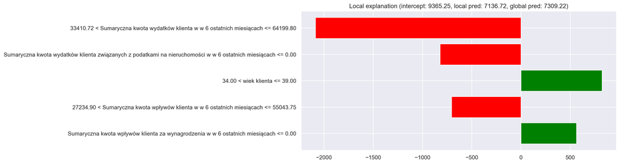

```python
xgb_exp = xgb_explainer.explain_instance(X_random_observations.to_numpy()[0].flatten(), xgb_predict, num_features=NUM_FEATURES)

fig = as_pyplot_figure(xgb_exp)
fig.savefig(f'../reports/figures/xgb_sample=0_num-features={NUM_FEATURES}.png')
```

```
Intercept 9857.167346416694
Prediction_local [3889.76363989]
Right: 6252.5635
```

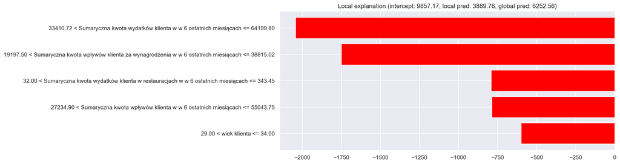

```python
xgb_exp = xgb_explainer.explain_instance(X_random_observations.to_numpy()[1].flatten(), xgb_predict, num_features=NUM_FEATURES)

fig = as_pyplot_figure(xgb_exp)
fig.savefig(f'../reports/figures/xgb_sample=1_num-features={NUM_FEATURES}.png')
```

```
Intercept 6130.175959229857
Prediction_local [15234.80568457]
Right: 23410.467
```

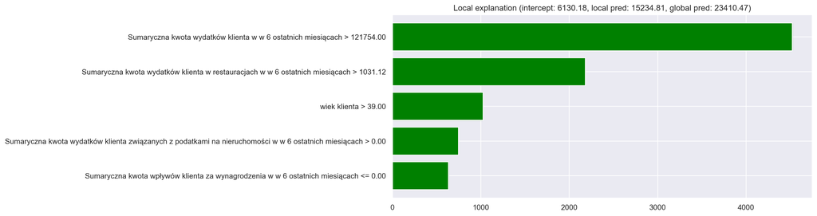

```python
xgb_exp = xgb_explainer.explain_instance(X_random_observations.to_numpy()[2].flatten(), xgb_predict, num_features=NUM_FEATURES)

fig = as_pyplot_figure(xgb_exp)
fig.savefig(f'../reports/figures/xgb_sample=2_num-features={NUM_FEATURES}.png')
```

```python
rf_best_params = {"n_estimators": 750, "max_features": 0.2969145621920279}
rf_model = ensemble.RandomForestRegressor(**rf_best_params)
rf_model.fit(X_train, np.log10(y_train + 1))
```

```
RandomForestRegressor(max_features=0.2969145621920279, n_estimators=750)
```

```python
rf_explainer = lime.lime_tabular.LimeTabularExplainer(
    X_train.to_numpy(),
    feature_names=feature_names,
    verbose=True,
    mode='regression'
)

rf_predict = lambda x: 10 ** rf_model.predict(x) - 1
```

```python
for sample in X_val.to_numpy():
    xgb_exp = xgb_explainer.explain_instance(sample, xgb_predict, num_features=NUM_FEATURES)
    rf_exp = rf_explainer.explain_instance(sample, rf_predict, num_features=NUM_FEATURES)

    xgb_exp_vars = set([var[0] for var in xgb_exp.as_list()])
    rf_exp_vars = set([var[0] for var in rf_exp.as_list()])

    print(len(xgb_exp_vars & rf_exp_vars))
    if len(xgb_exp_vars & rf_exp_vars) <= 3:
        break
```

```
Intercept 9835.379798676264
Prediction_local [4402.83101992]
Right: 4985.511
```

```
Intercept 9698.838411900942
Prediction_local [4339.42440018]
Right: 4836.988357511261
4
Intercept 7513.936199576837
Prediction_local [11154.00185341]
Right: 6687.5234
```

```
Intercept 7313.174358464872
Prediction_local [11441.21136185]
Right: 7433.236435838916
4
Intercept 6273.805371698954
Prediction_local [14625.97435377]
Right: 6899.0186
```

```
Intercept 6390.958134234117
Prediction_local [14134.93157647]
Right: 7363.842204208959
5
Intercept 10262.528560284505
Prediction_local [5224.76311982]
Right: 4000.0505
```

```
Intercept 9685.639972182687
Prediction_local [5525.33088145]
Right: 3668.453423541541
5
Intercept 7123.5557246256985
Prediction_local [9826.16326924]
Right: 7189.1367
```

```
Intercept 7159.646661990947
Prediction_local [10862.07722725]
Right: 8036.128154232835
4
Intercept 10031.886715161061
Prediction_local [5274.9048991]
Right: 3895.7842
```

```
Intercept 9966.165485048117
Prediction_local [4473.48224552]
Right: 4064.8815840539482
4
Intercept 6520.067533453627
Prediction_local [13838.77980053]
Right: 14250.327
```

```
Intercept 6197.352587154022
Prediction_local [14100.00454996]
Right: 14682.091733092644
3
```

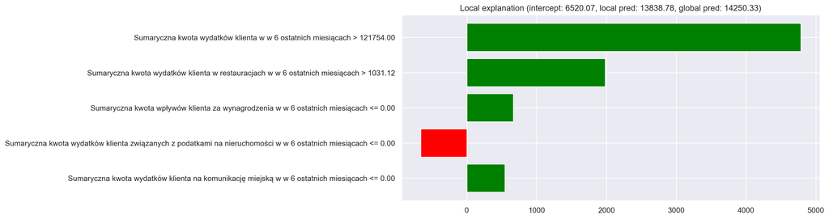

```python
fig = as_pyplot_figure(xgb_exp)
fig.savefig(f'../reports/figures/xgb_sample_num-features={NUM_FEATURES}.png')
```

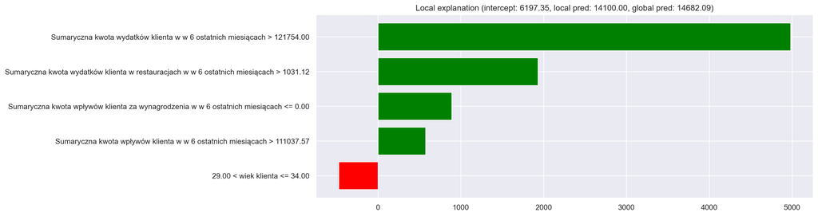

```python
fig = as_pyplot_figure(rf_exp)
fig.savefig(f'../reports/figures/rf_sample_num-features={NUM_FEATURES}.png')
```